# Analiza Danych - Laboratorium 3

Podstawy pakietu ggplot2

Adrian Kowalski

Politechnika Krakowska

# Pakiet ggplot2

Pakiet ggplot2 jest integralną częścią zestawu tidyverse. Służy do produkowania wysokiej jakości wizualizacji danych. Jego największą zaletą jest gramatyka bardzo mocno zintegrowana z pozostałymi pakietami tidyverse. Składnia ggplot2 pozwala równiesz na wysoki poziom swobody w dostosowywaniu grafik do własnych potrzeb i realizacji założonych celów. Wszelkich zainteresowanych pogłębieniem wiedzy na temat ggplot2 zachęcam do zaglądnięcia do darmowej [książki](https://ggplot2-book.org/index.html).

# Podstawowe wykresy w ggplot2

Grafika, która powstaje w ggplot2 składa się z trzech głównych części

1. danych,
2. estetyk (aesthetics),
3. geometrii (geometry).

Pierwszą rzeczą (oczywiście po wczytaniu pakietu), którą musimy zrobić w celu stworzenia grafiki jest stworzenie “płótna” i “estetyk”.

Płótno tworzymy za pomocą komendy ggplot.

```r
library(tidyverse)
```

```r
dataset1 <- readr::read_csv('ggplot_set1.csv')
print(dataset1)
```

```
## # A tibble: 365 × 5
##    Date        High   Low  Open Close
##    <date>     <dbl> <dbl> <dbl> <dbl>
##  1 2021-03-24  238   235.  238.  235.
##  2 2021-03-25  237.  232.  235.  232.
##  3 2021-03-26  237.  232.  232.  236.
##  4 2021-03-29  237.  232.  237.  235.
##  5 2021-03-30  234.  231.  234.  232.
##  6 2021-03-31  239.  232.  233.  236.
##  7 2021-04-01  243.  238.  238.  242.
##  8 2021-04-05  250.  243.  243.  249.
##  9 2021-04-06  249.  247.  248.  248.
## 10 2021-04-07  251.  247.  248.  250.
## # … with 355 more rows
```

## Wykres liniowy

```r
dataset1_plot1 <- ggplot(data = dataset1, aes(x = Date, y = Open))
```

Po zadaniu płótna i estetyk przechodzimy do rysowania. Zadaliśmy estetykę - na osi x będzie data, na osi y natomiat - cena otwarcia z danego dnia. Stworzymy zatem wykres liniowy przedstawiający te ceny otwarcia przy pomocy polecenia geom_line().

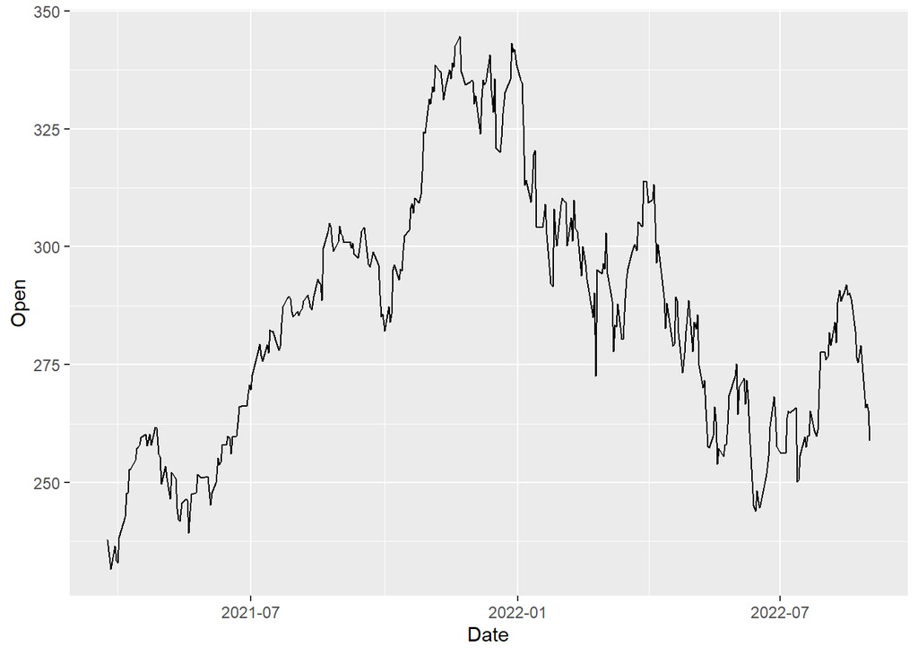

```r
dataset1_plot1 <- dataset1_plot1 + geom_line()
dataset1_plot1
```

### Nazwy osi

Czas nieco poprawić nasz wykres. Tytuły osi są zaczerpnięte bezpośrednio z nazw estetyk, zmieńmy je na polskie odpowiedniki za pomocą polecenia labs().

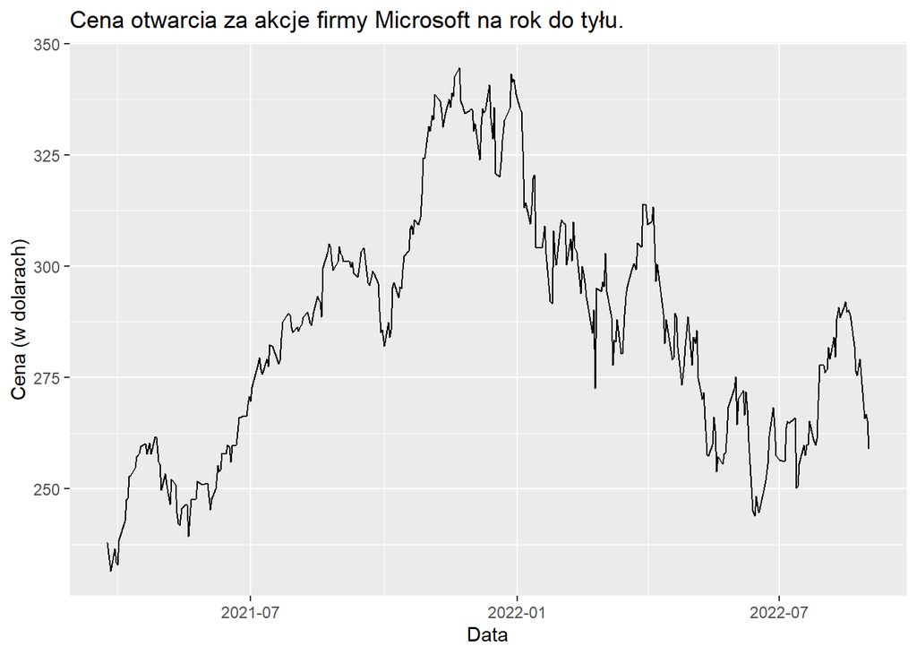

```r
dataset1_plot1_labeled <- dataset1_plot1 + labs(title='Cena otwarcia za akcje firmy Microsoft na rok do tyłu.', x='Data',
                                       y='Cena (w dolarach)')
dataset1_plot1_labeled
```

Taki sam efekt można otrzymać za pomocą poleceń xlab(), ylab(), ggtitle().

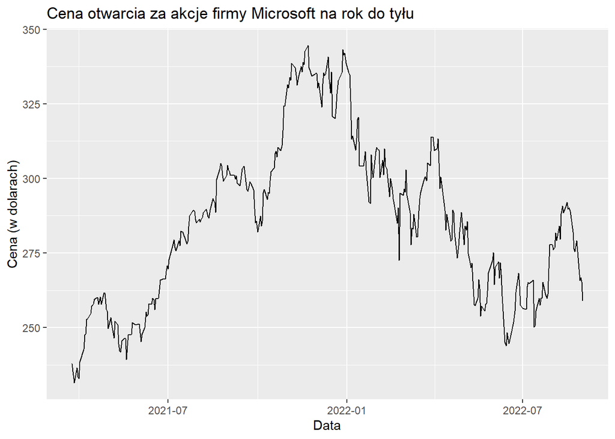

```r
dataset1_plot1_labeled2 <- dataset1_plot1 + xlab('Data') + ylab('Cena (w dolarach)') + ggtitle('Cena otwarcia za akcje firmy Microsoft na rok do tyłu')
dataset1_plot1_labeled2
```

Funkcja labs() ma jedynie przewagę, że w przyszłych zastosowaniach będziemy tam mogli umieszczać również podpisy do legendy.

### Etykiety osi

Etykiety osi i tytuły możemy edytować za pomocą polecenia theme() z odpowiednimi argumentami.

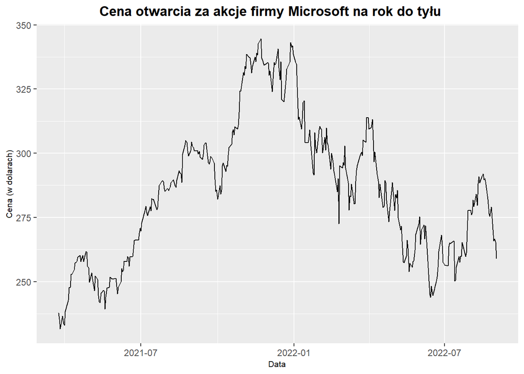

```r
dataset1_plot1_labeled2 <- dataset1_plot1_labeled2 + theme(
                          plot.title = element_text(hjust=0.45, face='bold'),
                          axis.title.x = element_text(size=8),
                          axis.title.y = element_text(size=8)
                          )
dataset1_plot1_labeled2
```

### Skale na osiach

Kolejnym pomysłem, jaki przychodzi do głowy na poprawę tego wykresu jest zagęszczenie skali na osi x.

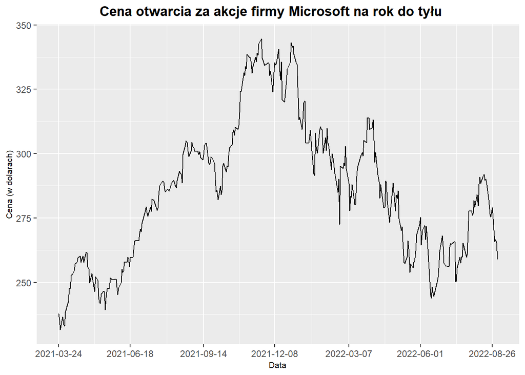

```r
dataset1_dates_ticks <- dataset1$Date[seq.int(1,length(dataset1$Date), 60)]
dataset1_plot1_labeled2 <- dataset1_plot1_labeled2 + scale_x_continuous(breaks = dataset1_dates_ticks)
dataset1_plot1_labeled2
```

Podpisami możemy manipulować, znowu, za pomocą theme().

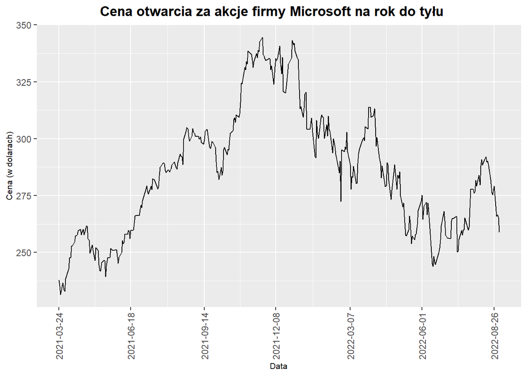

```r
dataset1_plot1_labeled2 <- dataset1_plot1_labeled2 + theme(axis.text.x=element_text(angle=90, vjust=0.5))
dataset1_plot1_labeled2
```

Zapanujmy teraz trochę nad skalą na osi y.

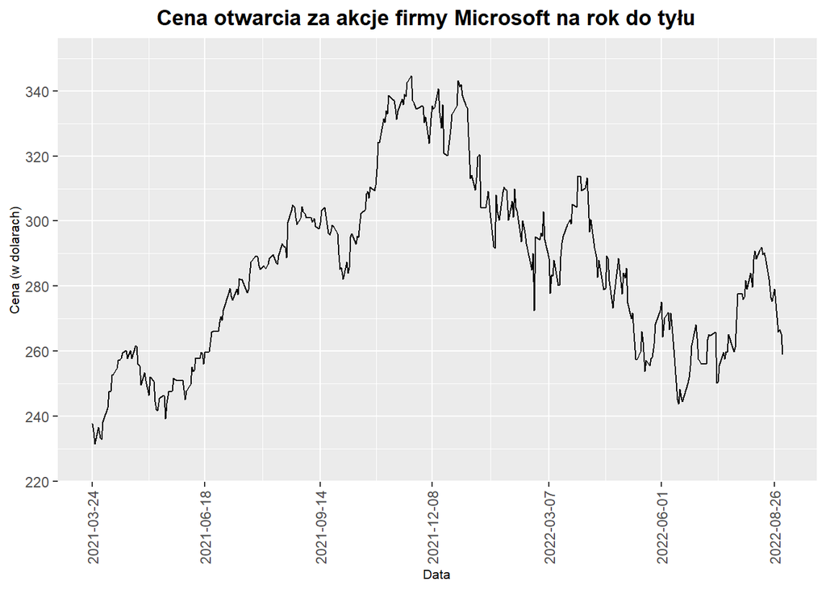

```r
dataset1_min_open <- floor(min(dataset1$Open)) - 5
dataset1_max_open <- ceiling(max(dataset1$Open)) + 5
dataset1_plot1_labeled2 <- dataset1_plot1_labeled2 + scale_y_continuous(limits=c(dataset1_min_open, dataset1_max_open), n.breaks = 10)
dataset1_plot1_labeled2
```

### Dodatkowe wykresy na tym samym płótnie

Dodamy teraz linie poziome zaznaczające nam minimalną i maksymalną cene otwarcia za pomocą geom_hline().

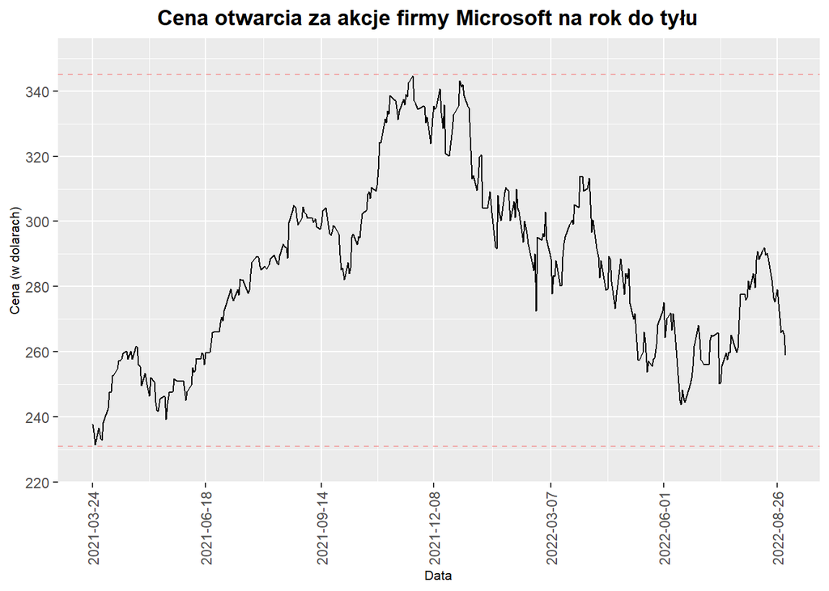

```r
dataset1_plot1_labeled2 <- dataset1_plot1_labeled2 + geom_hline(yintercept=dataset1_min_open+5, linetype='dashed',
                                                                color='red', alpha=0.3) +
                           geom_hline(yintercept=dataset1_max_open-5, linetype='dashed', color='red', alpha=0.3)

dataset1_plot1_labeled2
```

Pozostaje jedynie dodać podpisy do naszych linii poziomych. Zrobimy to za pomocą geom_text().

```r
dataset1_plot1_labeled3 <- dataset1_plot1_labeled2 + geom_text(aes(0, dataset1_min_open+5, label=dataset1_min_open+5, vjust=-1), size=2) + geom_text(aes(0, dataset1_max_open-5, label=dataset1_max_open-5, vjust=-1), size=2)
```

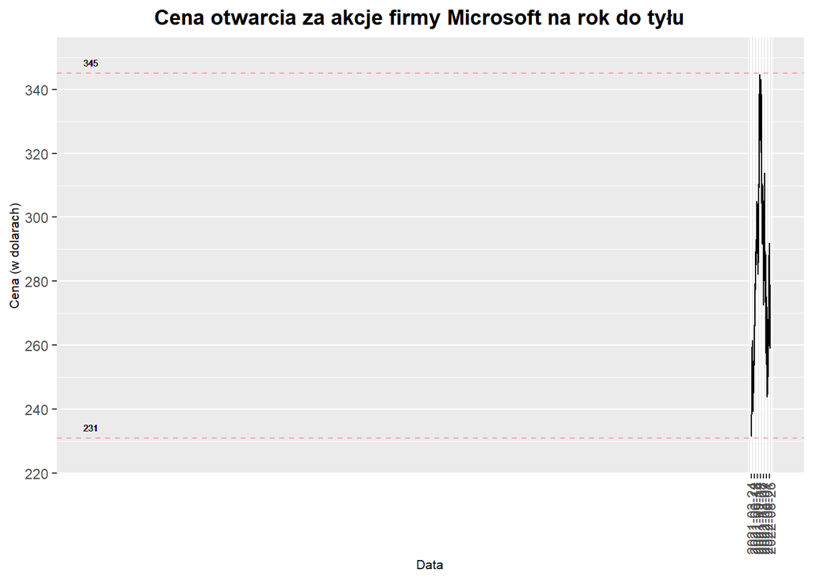

```r
print(dataset1_plot1_labeled3)
```

Ups, okazuje się, że automatycznie narzucone limity osi x nie są takie jakich byśmy się spodziewali. Możemy zajrzeć do parametrów naszego obiektu przy pomocy ggplot_build().

Uwaga: ggplot_build() zwraca bardzo dużo parametrów naszego obrazka. Należy najpierw zajrzeć do dokumentacji po potrzebny nam parametr i “wyciągnąć go” manualnie.

```r
dataset1_plot1_xlims <- ggplot_build(dataset1_plot1_labeled2)$layout$panel_params[[1]]$x.range
```

```r
dataset1_plot1_labeled3 <- dataset1_plot1_labeled2 + geom_text(aes(dataset1_plot1_xlims[1], dataset1_min_open+5, label=dataset1_min_open+5, vjust=-1), size=2) + geom_text(aes(dataset1_plot1_xlims[1], dataset1_max_open-5, label=dataset1_max_open-5, vjust=-1), size=2)
```

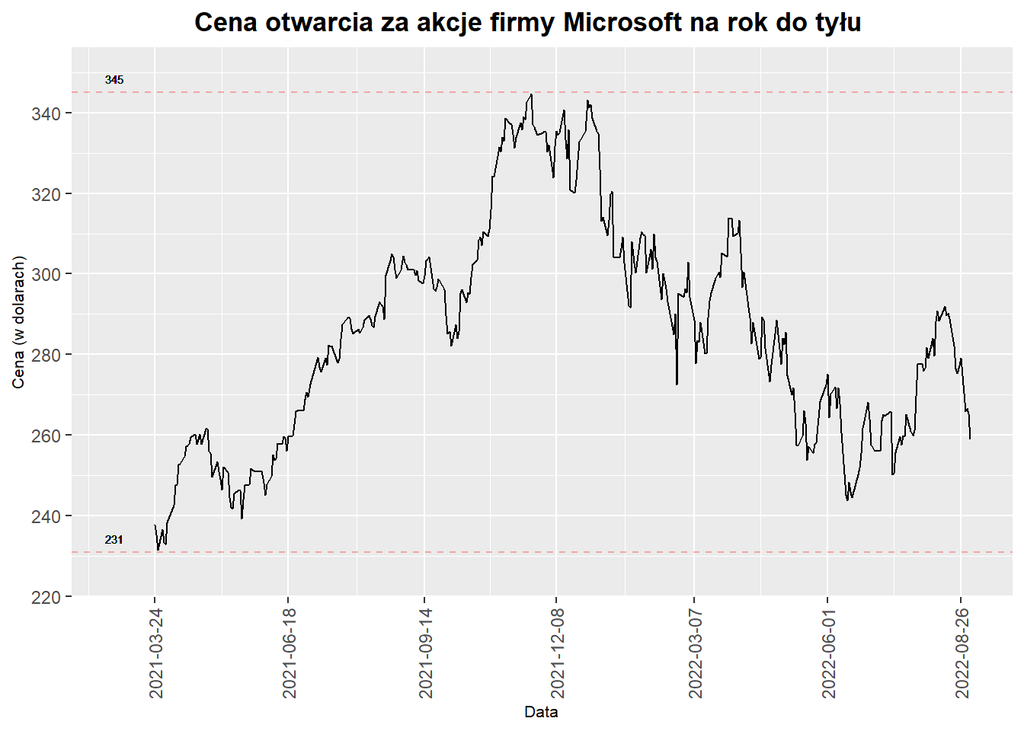

```r
dataset1_plot1_labeled3
```

Równie dobrze można było podpisać jedynie znaczniki na osi y. Zrobimy to następującym sposobem.

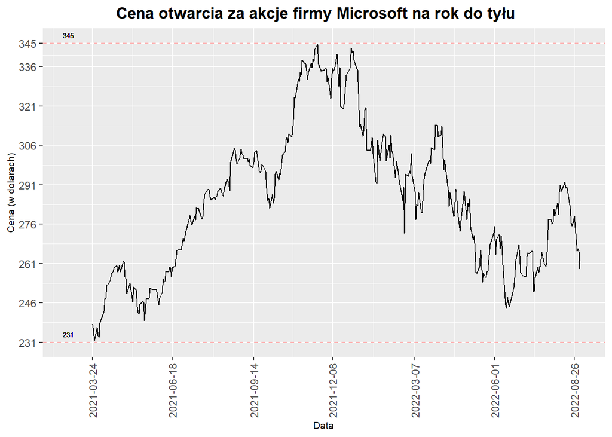

```r
dataset1_plot1_breaks2 <- sort(c(seq(dataset1_min_open+5, dataset1_max_open - 5, 15), dataset1_max_open -5))
dataset1_plot1_labeled3 <- dataset1_plot1_labeled3 + scale_y_continuous(breaks= dataset1_plot1_breaks2)
dataset1_plot1_labeled3
```

### Wiele linii na jednym wykresie

Na jednym wykresie liniowym możemy zamieścić wiele linii.

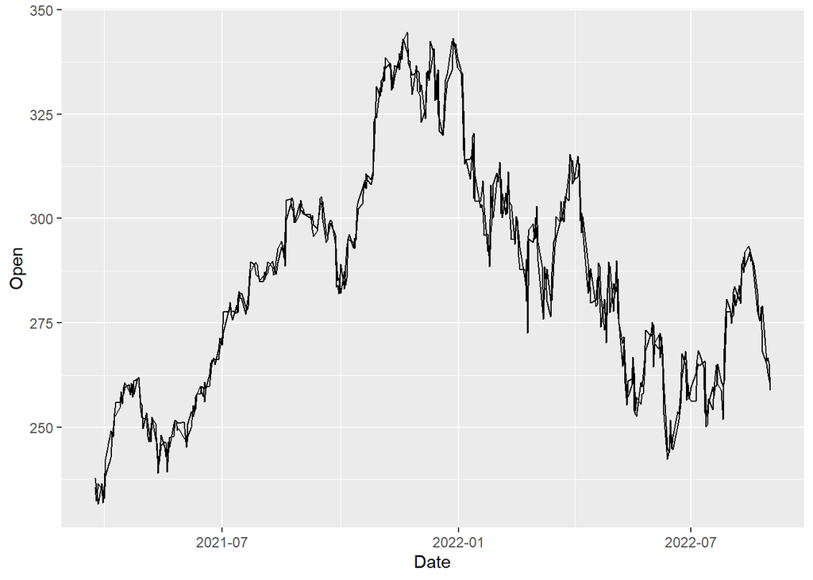

```r
dataset1_plot2 <- dataset1_plot1 + geom_line(aes(y = Close))
dataset1_plot2
```

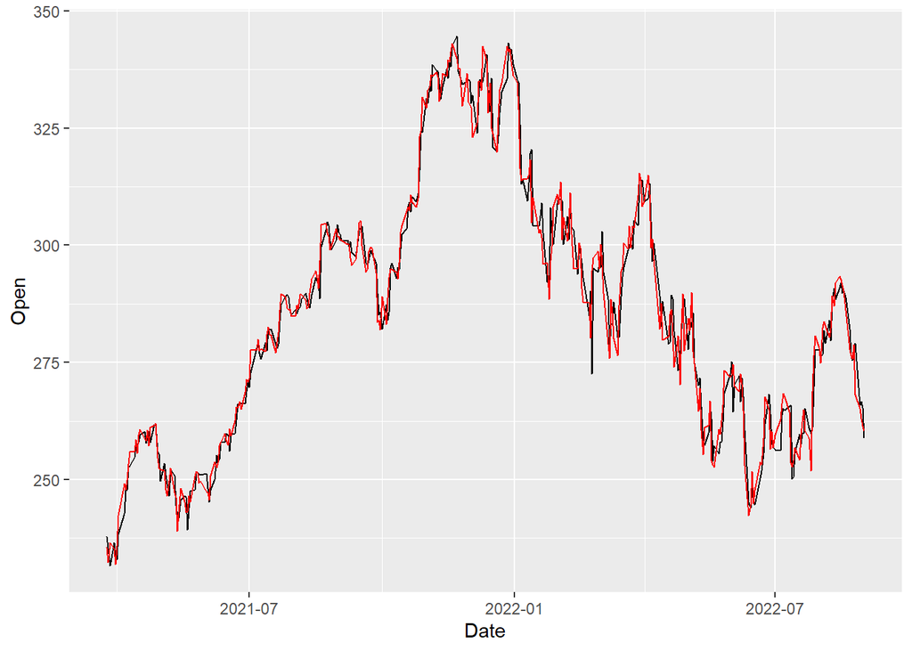

```r
dataset1_plot3 <- dataset1_plot1 + geom_line(aes(y=Close), color='red')
dataset1_plot3
```

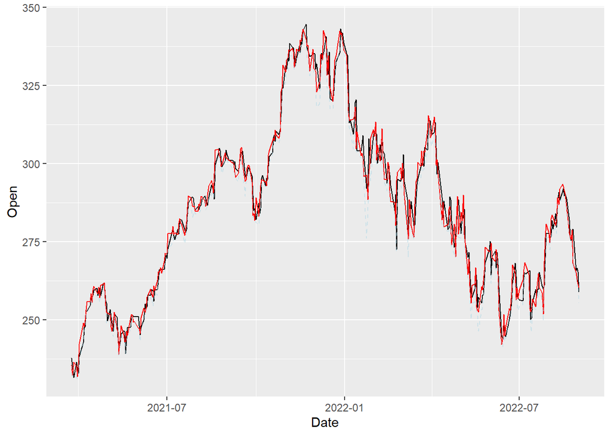

```r
dataset1_plot3 <- dataset1_plot3 + geom_line(aes(y=Low), linetype='dashed', alpha=0.5, color='lightblue')
dataset1_plot3
```

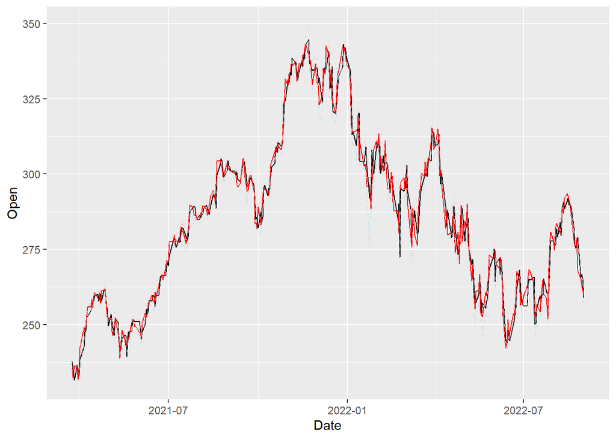

```r
dataset1_plot3 <- dataset1_plot3 + geom_line(aes(y=High), linetype='dashed', alpha=0.5, color='pink')
dataset1_plot3
```

Istnieje na to również druga, preferowana, metoda. Odpowiednio przygotowując dane do stworzenia wykresu jesteśmy w stanie dużo oszczędniej i w bardziej kontrolowany sposóB przygotować obrazek.

```r
dataset1_lineplot <- dataset1 %>% pivot_longer(2:5, names_to='price_type', values_to='price') %>%
                    mutate(pl_alpha=ifelse((price_type=='High')|(price_type=='Low'), 0.5, 1)) %>%
                    mutate(pl_linetype=ifelse((price_type=='High')|(price_type=='Low'),'dashed','solid'))
dataset1_lineplot
```

| Date | price_type | price | pl_alpha | pl_linetype |
| --- | --- | --- | --- | --- |
| 2021-03-24 | High | 238.00 | 0.5 | dashed |
| 2021-03-24 | Low | 235.32 | 0.5 | dashed |
| 2021-03-24 | Open | 237.85 | 1.0 | solid |
| 2021-03-24 | Close | 235.46 | 1.0 | solid |
| 2021-03-25 | High | 236.94 | 0.5 | dashed |
| 2021-03-25 | Low | 231.57 | 0.5 | dashed |
| 2021-03-25 | Open | 235.30 | 1.0 | solid |
| 2021-03-25 | Close | 232.34 | 1.0 | solid |
| 2021-03-26 | High | 236.71 | 0.5 | dashed |
| 2021-03-26 | Low | 231.55 | 0.5 | dashed |

[output cut: 1450 more lines]

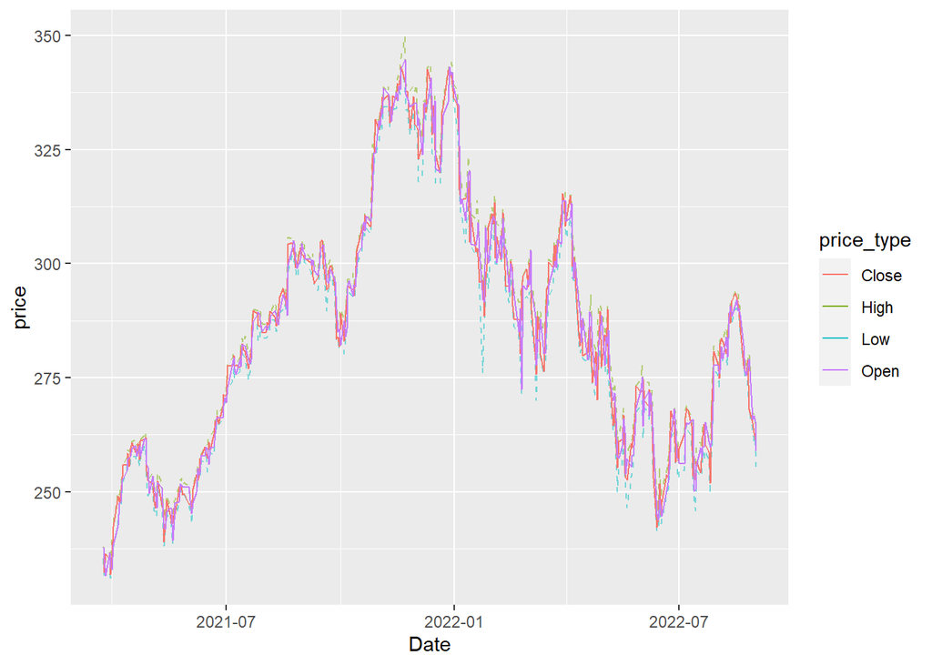

```r
dataset1_plot4 <- ggplot(dataset1_lineplot, aes(x=Date, y=price, color=price_type)) +               geom_line(aes(alpha=pl_alpha, linetype=pl_linetype)) + scale_alpha_identity() + scale_linetype_identity()
dataset1_plot4
```

# Ćwiczenie

Uzbrojony w powyższe informacje o podstawowych funkcjonalnościach pakietu ggplot2 wykonaj histogram, wykres punktowy z podziałem na kolory i rozmiary punktów oraz wykres pudełkowy korzystając z poniższych danych.

```r
mpg
```

| manufacturer | model | displ | year | cyl | trans | drv | cty | hwy | fl | class |
| --- | --- | --- | --- | --- | --- | --- | --- | --- | --- | --- |
| audi | a4 | 1.8 | 1999 | 4 | auto(l5) | f | 18 | 29 | p | compact |
| audi | a4 | 1.8 | 1999 | 4 | manual(m5) | f | 21 | 29 | p | compact |
| audi | a4 | 2.0 | 2008 | 4 | manual(m6) | f | 20 | 31 | p | compact |
| audi | a4 | 2.0 | 2008 | 4 | auto(av) | f | 21 | 30 | p | compact |
| audi | a4 | 2.8 | 1999 | 6 | auto(l5) | f | 16 | 26 | p | compact |
| audi | a4 | 2.8 | 1999 | 6 | manual(m5) | f | 18 | 26 | p | compact |
| audi | a4 | 3.1 | 2008 | 6 | auto(av) | f | 18 | 27 | p | compact |
| audi | a4 quattro | 1.8 | 1999 | 4 | manual(m5) | 4 | 18 | 26 | p | compact |
| audi | a4 quattro | 1.8 | 1999 | 4 | auto(l5) | 4 | 16 | 25 | p | compact |
| audi | a4 quattro | 2.0 | 2008 | 4 | manual(m6) | 4 | 20 | 28 | p | compact |

[output cut: 224 more lines]

Wskazówka: Dokumentacje do danych mpg z pakietu ggplot2 znajdziemy wpisując *?mpg*

Wskazówka 2: Histogram wykonujemy za pomocą polecenia *geom_hist()*, wykres punktowy *geom_point()*, wykres pudełkowy *geom_boxplot()*.